# week09 - answer

```python
print('Hello World!')
```

```
Hello World!
```

#### 简单的python匹配

```python
a = '111'
b = '1111'
c = '111222333'
print(a in b)
print(b in c)

# print(b.index(a))
```

```
True
False
```

### re模块

Python提供`re`模块，包含所有正则表达式的功能。由于Python的字符串本身也用`\`转义，所以要特别注意：

```python
s = 'ABC\\n001' # Python的字符串
# 对应的正则表达式字符串变成：
# 'ABC\n001'
print(s)

# 建议使用Python的`r`前缀（表示原生字符串），就不用考虑转义的问题了：
s = r'ABC\n001' # Python的字符串
# 对应的正则表达式字符串不变：
# 'ABC\n001'
print(s)
```

```
ABC\n001
ABC\n001
```

建议使用Python的`r`前缀（表示raw原生字符串），就不用考虑转义的问题了：

```python
s1 = '\n'
s2 = '\\n'
s3 = r'\n'
s4 = '\n\\n'
print(s1)
print(s2)
print(s3)
print(s4)
```

```
\n
\n

\n
```

#### 简单的re搜索

```python
import re

a = '111'
b = '1111'
c = '111222333'
print(re.search(a, b))
print(re.search(b, c))
```

```
<re.Match object; span=(0, 3), match='111'>
None
```

## 正则表达式

正则表达式是对字符串操作的一种逻辑公式，就是用事先定义好的一些特定字符、及这些特定字符的组合，组成一个“规则字符串”，这个“规则字符串”用来表达对字符串的一种过滤逻辑。正则表达式用字符串表示。

### 基本用法

在正则表达式中，如果直接给出字符，就是精确匹配。用`\d`可以匹配一个数字，`\w`可以匹配一个字母或数字，所以：

- `'00\d'`可以匹配`'007'`，但无法匹配`'00A'`；
- `'\d\d\d'`可以匹配`'010'`
- `'\w\w\d'`可以匹配`'py3'`

`.`可以匹配任意字符，所以：

- `'py.'`可以匹配`'pyc'`、`'pyo'`、`'py!'`等等（"."匹配除换行符"\n"以外的字符）

要匹配变长的字符，在正则表达式中，用`*`表示任意个字符（包括0个），用`+`表示至少1个字符，用`?`表示0个或1个字符，用`{n}`表示n个字符，用`{n,m}`表示n-m个字符。如：`\d{3}\s+\d{3,8}`

- `\d{3}`表示匹配3个数字，例如`'010'`
- `\s`可以匹配一个空格（也包括Tab等空白符），所以`\s+`表示至少有一个空格，例如匹配`' '`，`' '`等
- `\d{3,8}`表示3-8个数字，例如`'1234567'`

# 更深入见：https://cuiqingcai.com/977.html

```python
# \d 数字 [0-9]
print(re.search(r'\d', r'ABCD1234E'))
print(re.search(r'\d\d', r'ABCD1234E'))
# \w 数字 [a-zA-Z0-9_]
print(re.search(r'\w\w\d', r'ABCD1234E'))
print(re.search(r'\w\w\d', r'ABCD_1234E'))
print(re.search(r'\w\w\d', r'ABCD~1234E'))
print(re.search(r'\w.\d', r'ABCD~1234E'))
```

```
<re.Match object; span=(4, 5), match='1'>
<re.Match object; span=(4, 6), match='12'>
<re.Match object; span=(2, 5), match='CD1'>
<re.Match object; span=(3, 6), match='D_1'>
<re.Match object; span=(5, 8), match='123'>
<re.Match object; span=(3, 6), match='D~1'>
```

```python
# 长度不定匹配
print(re.search(r'\d{2}', r'ABCD1234E'))
print(re.search(r'\d{2,5}', r'ABCD1234E'))
print(re.search(r'\d+', r'ABCD1234E'))
# \s 空白符 [\t\n\r\f\v]
print(re.search(r'\s\d', r'ABCD      1234E'))
```

```
<re.Match object; span=(4, 6), match='12'>
<re.Match object; span=(4, 8), match='1234'>
<re.Match object; span=(4, 8), match='1234'>
<re.Match object; span=(9, 11), match=' 1'>
```

```python
# \D 非数字形式 not [0-9]
print(re.search(r'\w\w\d', r'ABCD~1234E'))
# \S 非空格形式 not [\t\n\r\f\v]
print(re.search(r'\S{2,5}', '\t\r\n\v\f1234\t\r\n\v\f'))
# \W not [a-zA-Z0-9_]
print(re.search(r'\W\d', r'ABCD~1234E'))
```

```
<re.Match object; span=(5, 8), match='123'>
<re.Match object; span=(5, 9), match='1234'>
<re.Match object; span=(4, 6), match='~1'>
```

### 进阶

要做更精确地匹配，可以用`[]`表示范围

- `[0-9a-zA-Z\_]`可以匹配一个数字、字母或者下划线
- `[0-9a-zA-Z\_]+`可以匹配至少由一个数字、字母或者下划线组成的字符串，比如`'a100'`，`'0_Z'`，`'Py3000'`等等
- `[a-zA-Z\_][0-9a-zA-Z\_]*`可以匹配由字母或下划线开头，后接任意个由一个数字、字母或者下划线组成的字符串，也就是Python合法的变量
- `[a-zA-Z\_][0-9a-zA-Z\_]{0, 19}`更精确地限制了变量的长度是1-20个字符（前面1个字符+后面最多19个字符）

`A|B`可以匹配A或B，所以`(P|p)ython`可以匹配`'Python'`或者`'python'`

`^`表示行的开头，`^\d`表示必须以数字开头

`$`表示行的结束，`\d$`表示必须以数字结束

```python
# 内容范围匹配
print(re.search(r'H[ia]', r'Hi, XXX'))
print(re.search(r'H[ia]', r'Ha, XXX'))
print()
print(re.search(r'[A-Z][0-9]', r'ABCD1234E'))
print(re.search(r'\w[A-Z~!@#$%^&]\d', r'ABCD~1234E'))
print(re.search(r'\w[A-Z~!@#$%^&]{2,5}\d', r'ABCD~1234E'))
```

```
<re.Match object; span=(0, 2), match='Hi'>
<re.Match object; span=(0, 2), match='Ha'>

<re.Match object; span=(3, 5), match='D1'>
<re.Match object; span=(3, 6), match='D~1'>
<re.Match object; span=(0, 6), match='ABCD~1'>
```

```python
print(re.search(r'^\w+', r'ABCD1234'))
print(re.search(r'\w+$', r'ABCD1234'))
print()
print(re.search(r'([A-Z]|[0-9])\w+', r'ABCD1234'))
print(re.search(r'([A-Z]|[0-9]){4,8}', r'ABCD1234'))
print(re.search(r'([A-Z]|[0-9])\d+', r'1234ABCD'))
print(re.search(r'([A-Z]|[0-9]){4,8}', r'1234ABCD'))
print()
print(re.search(r'([A-Z0-9]){4,8}', r'1234ABCD'))
print(re.search(r'([a-zA-Z0-9]){4,12}', r'abcd1234ABCD'))
```

```
<re.Match object; span=(0, 8), match='ABCD1234'>
<re.Match object; span=(0, 8), match='ABCD1234'>

<re.Match object; span=(0, 8), match='ABCD1234'>
<re.Match object; span=(0, 8), match='ABCD1234'>
<re.Match object; span=(0, 4), match='1234'>
<re.Match object; span=(0, 8), match='1234ABCD'>

<re.Match object; span=(0, 8), match='1234ABCD'>
<re.Match object; span=(0, 12), match='abcd1234ABCD'>
```

```python
# . 通配符
print(re.search(r'C.n', r'1234ABCDn'))
print(re.search(r'D.b', '1234ABCD\rb'))
print(re.search(r'D.b', '1234ABCD\nb'))    # 不包括\n
print()

# ? 是否有(没有也可匹配)
print(re.search(r'BC?D', r'1234ABCDn'))
print(re.search(r'BC?D', r'1234ABDn'))
print(re.search('CD\n?b', '1234ABCDb'))
print(re.search('CD\n?b', '1234ABCD\nb'))
print()

# * 0或多次
print(re.search('CD*b', '1234ABCb'))
print(re.search('CD*b', '1234ABCDDDDDb'))
```

```
<re.Match object; span=(6, 9), match='CDn'>
<re.Match object; span=(7, 10), match='D\rb'>
None

<re.Match object; span=(5, 8), match='BCD'>
<re.Match object; span=(5, 7), match='BD'>
<re.Match object; span=(6, 9), match='CDb'>
<re.Match object; span=(6, 10), match='CD\nb'>

<re.Match object; span=(6, 8), match='Cb'>
<re.Match object; span=(6, 13), match='CDDDDDb'>
```

##### 贪婪匹配

正则匹配默认是贪婪匹配，也就是匹配尽可能多的字符。举例如下，匹配出数字后面的0：

```python
print(re.match(r'^(\d+)(0*)$', '102300').groups()) # '*': 匹配前一个字符0次或无限次
print(re.match(r'^(\d+)(0+)$', '102300').groups()) # '+': 匹配前一个字符1次或无限次
```

```
('102300', '')
('10230', '0')
```

由于`\d+`采用贪婪匹配，直接把后面的0全部匹配了，结果`0*`只能匹配空字符串了。

必须让`\d+`采用非贪婪匹配（也就是尽可能少匹配），才能把后面的0匹配出来，加个`?`就可以让`\d+`采用非贪婪匹配：

```python
re.match(r'^(\d+?)(0*)$', '100200').groups()
```

```
('1002', '00')
```

注：我们一般使用非贪婪模式来提取。

##### 如何判断正则表达式是否匹配：

- 返回pattern对象:可以理解为一个匹配模式。在参数中传入原生字符串对象，通过compile方法编译生成一个pattern对象，然后利用这个对象进行进一步的匹配。

  pattern = re.compile(string[,flags]) flags表示匹配模式

```python
pattern = re.compile(r'hello')
pattern
```

[output not shown]

- 参数flags: 匹配模式，取值可以使用运算符'|'表示同时生效。可选值有：

  re.I (IGNORECASE): 忽略大小写（括号内是完整写法，下同）

  re.M (MULTILINE): 多行模式，改变'^'和'$'的行为

  re.S (DOTALL): 点任意匹配模式，改变'.'的行为

  re.L (LOCALE): 使预定字符类 \w \W \b \B \s \S 取决于当前区域设定

  re.U (UNICODE): 使预定字符类 \w \W \b \B \s \S \d \D 取决于unicode定义的字符属性

  re.X (VERBOSE): 详细模式。这个模式下正则表达式可以是多行，忽略空白字符，并可以加入注释。

```python
# 多行匹配
s = '''aaa
bbb
ccc
ddd'''
print(re.search('^c', s))
print(re.search('^c', s, re.M))
```

```
None
<re.Match object; span=(8, 9), match='c'>
```

### 编译

当我们在Python中使用正则表达式时，re模块内部会干两件事情：

- 编译正则表达式，如果正则表达式的字符串本身不合法，会报错；
- 用编译后的正则表达式去匹配字符串。

如果一个正则表达式要重复使用几千次，出于效率的考虑，我们可以预编译该正则表达式，接下来重复使用时就不需要编译这个步骤了，直接匹配

```python
import re
re_telephone = re.compile(r'^(\d{3})-(\d{3,8})$', re.S)
print(re_telephone.match('010-12345').groups())
print(re_telephone.match('010-8086').groups())
```

```
('010', '12345')
('010', '8086')
```

编译后生成Regular Expression对象，由于该对象自己包含了正则表达式，所以调用对应的方法时不用给出正则字符串。

`re.S`它表示`.`的作用扩展到整个字符串，包括`\n`。如果没有这个标记，`.` 就匹配**除了**换行符的其他任意字符。

```python
a = '''asdfhellopass:
    123
    worldaf
    '''
b = re.findall('hello(.*?)world', a) #'.'：匹配任意除换行符之外的字符；'*'：匹配前一个字符0或无数次；'?'：非贪婪
c = re.findall('hello(.*?)world', a, re.S)
print(b)
print(c)
```

```
[]
['pass:\n    123\n    ']
```

正则表达式中，`.`的作用是匹配除`\n`以外的任何字符，也就是说，它是在一行中进行匹配。这里的“行”是以`\n`进行区分的。a字符串有每行的末尾有一个`\n`，不过它不可见。

如果不使用`re.S`参数，则只在每一行内进行匹配，如果一行没有，就换下一行重新开始，不会跨行。而使用`re.S`参数以后，正则表达式会将这个字符串作为一个整体，将`\n`当做一个普通的字符加入到这个字符串中，在整体中进行匹配。

### re.match(pattern, string[, flags])

这个方法将会从string（我们要匹配的字符串）的开头开始，尝试匹配pattern，一直向后匹配，如果遇到无法匹配的字符，立即返回None，如果匹配未结束已经到达string的末尾，也会返回None。两个结果均表示匹配失败，否则匹配pattern成功，返回一个`Match`对象，同时匹配终止，不再对string向后匹配。

- 以下为匹配所用函数

  re.match(pattern,string[,flags])

  re.search(pattern,string[,flags])

  re.split(pattern,string[,maxsplit])

  re.findall(pattern,string[,flags])

  re.finditer(pattern,string[,flags])

  re.sub(pattern,repl,string[,count])

  re.subn(pattern,repl,string[,count])

  注：如果在pattern生成时已经指明了flags，那么在下面的方法中就不需要传入这个参数了。

```python
#导入re模块
import re

#将正则表达式编译成Pattern对象，注意hello前面的r的意思是“原生字符串”
pattern = re.compile(r'hello')

#使用re.match匹配文本，获得匹配结果，无法匹配时将返回None
result1 = re.match(pattern,'hello')
result2 = re.match(pattern,'helloo CQC!')
result3 = re.match(pattern,'helo CQC!')
result4 = re.match(pattern,'hello CQC!')

#如果1匹配成功
if result1:
    #使用match获得分组信息
    print(result1.group())
else:
    print('1匹配失败！')

#如果2匹配成功
if result2:
    print(result2.group())
else:
    print('2匹配失败！')

#如果3匹配成功
if result3:
    print(result3.group())
else:
    print('3匹配失败！')

#如果4匹配成功
if result4:
    print(result4.group())
else:
    print('4匹配失败！')
```

```
hello
hello
3匹配失败！
hello
```

```python
print("result2.string:", result2.string) #匹配时使用的文本
print("result2.re:", result2.re)         #匹配时使用的Pattern对象
print("result2.pos:", result2.pos)       #文本中正则表达式开始搜索的索引
print("result2.endpos:", result2.endpos) #文本中正则表达式结束搜索的索引
```

```
result2.string: helloo CQC!
result2.re: re.compile('hello')
result2.pos: 0
result2.endpos: 11
```

### re.search(pattern, string[, flags])

search方法与match方法极其类似，区别在于`match()`函数只检测re是不是在string的开始位置匹配，`search()`会扫描整个string查找匹配，`match()`只有在0位置匹配成功的话才有返回，如果不是开始位置匹配成功的话，`match()`就返回None。

```python
# match（）函数只检测RE是不是在string的开始位置匹配，
# search()会扫描整个string查找匹配
# match（）只有在0位置匹配成功的话才有返回，如果不是开始位置匹配成功的话，match()就返回none

print(re.match('super','insuperable'))
print(re.search('super','insuperable'))
```

```
None
<re.Match object; span=(2, 7), match='super'>
```

```python
import re

pattern = re.compile(r'world')
# 使用search()查找匹配的子串，不存在能匹配的子串时将返回None
# 这个例子中使用match()无法成功匹配
match = re.search(pattern, 'hello world 2 world!')
if match:
    # 使用Match获得分组信息
    print(match.group())

match1 = re.match(pattern,'hello world 2 world!')
print(match1)
```

```
world
None
```

### 分组

除了简单地判断是否匹配之外，正则表达式还有提取子串的强大功能。用`()`表示的就是要提取的分组（Group）。

如果正则表达式中定义了组，就可以在`Match`对象上用`group()`方法提取出子串来。

注意到`group(0)`永远是原始字符串（不填写参数时返回group(0))，`group(1)`、`group(2)`……表示第1、2、……个子串。没有截获字符串的组返回None；截获了多次的组返回最后一次截获的子串。

比如：`^(\d{3})-(\d{3,8})$`分别定义了两个组，可以直接从匹配的字符串中提取出区号和本地号码：

```python
if re.match(r'^\d{3}-\d{3,8}$', '010-12'):
    print(re.match(r'^\d{3}-\d{3,8}$', '010-12').group())
print(re.match(r'^\d{3}-\d{3,8}$', '010-12345').group())
print(re.match(r'^\d{3}-\d{3,8}', '010-123455675090904'))
#要求以3位数开头，-，没说横杠后是3-8位，所以贪婪匹配
```

```
010-12345
<re.Match object; span=(0, 12), match='010-12345567'>
```

```python
# 用括号分组
m = re.match(r'^(\d{3})-(\d{3,8})$', '010-12345') #^匹配字符串的开头， $匹配字符串的结尾
print(m)
print(m.group(0))    # 返回整个结果
print(m.group())
print(m.group(1))
print(m.group(2))
```

[output not shown]

```python
m = re.search(r'(\d+), Date:(.+)', r'ID:010, Date:12/12/2345')
print(m.group(1))
print(m.group(2))
print()

# 给分组打标签
m = re.search(r'(?P<i>\d+), Date:(?P<date>.+)', r'ID:010, Date:12/12/2345')
print(m.group(1))
print(m.group(2))
print(f'ID: {m.group("id")}')    # 注意单双引号
print(f'Date: {m.group("date")}')
```

[output not shown]

### re.findall(pattern, string[, flags])

搜索string，以**列表**形式返回全部能匹配的子串

```python
import re

pattern = re.compile(r'\d+')
print(re.findall(pattern,'one1two2three3four4'))
```

```
['1', '2', '3', '4']
```

### 应用

```python
import requests
url = 'http://www.nsd.pku.edu.cn/'
headers = {'User-Agent': "Mozilla/5.0 (Windows NT 6.2; WOW64) AppleWebKit/535.24 (KHTML, like Gecko) Chrome/19.0.1055.1 Safari/535.24"}
try:
    response = requests.get(url, headers=headers, timeout=20)
    response.encoding = 'utf-8'
    if response.status_code != 200:
        print('网页内容获取失败')
    else:
        html = response.text
except:
    print('抓取失败')

# print(html)

#关键：生成正则表达式
pattern = re.compile(r'<h4 class="title"><a href="(.*?)" title="(.*?)">', re.S)
items = re.findall(pattern, html)

# print(type(items))
# print(items)
for item in items:
    print(item[0])
    print(item[1])
    print('\n')
```

```
sylm/xw/522333.htm
专访 | 余淼杰：为什么说取消冗余的交通收费站，是建设统一大市场应有之义？


sylm/xw/522325.htm
国家发展研究院党委举行2021年度党支部书记述职评议会


sylm/xw/522338.htm
《可持续发展金融前沿》月报（2022年第3期）


https://mp.weixin.qq.com/s/35ErfRpKdfYLTs5e9WpIpg
第四届国家发展青年论坛初审结果公告


sylm/xw/522298.htm
《21世纪经济报道》专访余淼杰：区域市场一体化建设最终目标是形成全国统一大市场


sylm/xw/522288.htm
黄益平、王勋老师合著的新书《读懂中国金融：金融改革的经济学分析》出版


sylm/xw/522221.htm
《每日经济新闻 》访余淼杰：落实《加快建设全国统一大市场的意见》的关键


https://mp.weixin.qq.com/s/N8sB0qRlJV7sh-nCSqeT5A
专访 | 宫玉振：不确定环境下的关键领导力


sylm/xw/522188.htm
《天目新闻》专访卢锋：罕见缩表在即 美联储意欲何为？


https://mp.weixin.qq.com/s/yx30V3rar9sBv5_u2auG3A
清明追思，家国永念——国发院党团支部参观北京大学革命英烈主题展


```

[output cut: 231 more lines]

```

http://ile.nsd.pku.edu.cn/
法律经济学研究中心


http://cced.nsd.pku.edu.cn/
能源安全与国家发展研究中心


http://chcp.nsd.pku.edu.cn/
人力资本与国家政策研究中心


http://ccher.nsd.pku.edu.cn/
中国卫生经济研究中心
```

#### 练习1

给出如下字符串形式 , 使用正则表达式匹配小数

```python
import numpy as np
a = f'这个小数是: {str(np.random.rand()+np.random.randint(65535))}'
print(a)

print(re.search(r'[0-9]+\W[0-9]+', a))
```

```
这个小数是: 8328.349104166697
<re.Match object; span=(7, 24), match='8328.349104166697'>
```

#### 练习2

给出如下营销号文案  
自定义名字，事件，原因

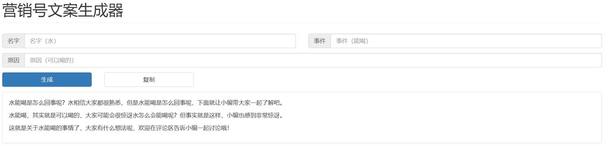

使用正则匹配出名字，事件，原因

```python
wd = '水'
event = '能喝'
reason = '可以喝的'
text = f'''{wd}{event}是怎么回事呢？{wd}相信大家都很熟悉，但是{wd}{event}是怎么回事呢，下面就让小编带大家一起了解吧。
{wd}{event}，其实就是{reason}，大家可能会很惊讶{wd}怎么会{event}呢？但事实就是这样，小编也感到非常惊讶。
这就是关于{wd}{event}的事情了，大家有什么想法呢，欢迎在评论区告诉小编一起讨论哦！'''
print(text+'\n')

m = re.search(r'其实就是(?P<reason>\w+)，大家可能会很惊讶(?P<wd>\w+)怎么会(?P<event>\w+)呢？', text)
print(f'名字: {m.group("wd")}')
print(f'事件: {m.group("event")}')
print(f'原因: {m.group("reason")}')
```

```
水能喝是怎么回事呢？水相信大家都很熟悉，但是水能喝是怎么回事呢，下面就让小编带大家一起了解吧。
水能喝，其实就是可以喝的，大家可能会很惊讶水怎么会能喝呢？但事实就是这样，小编也感到非常惊讶。
这就是关于水能喝的事情了，大家有什么想法呢，欢迎在评论区告诉小编一起讨论哦！

名字: 水
事件: 能喝
原因: 可以喝的
```

#### 练习3

给出如下多行，不同格式的时间字符串，将其转为`XXXX年XX月XX日 XX:XX:XX`的格式输出

```python
text=r'''2022年04月20日00:00:00
22年4月15日3:02:02
81-12-3118:00:00
32\7\1 6:1:5
1951//06//0101:01:01
2022\\7\\095:5:5
2022Y12M31D13:23:33'''

pattern = re.compile(r'^(?P<y>\d{2,4})[\w\W]+?(?P<m>\d{1,2})[\w\W]+?(?P<d>\d{1,2})[\w\W]*?(?P<t>\d{1,2}:\d{1,2}:\d{1,2})$', re.M)
items = re.findall(pattern, text)

# print(type(items))
# print(items)
for item in items:
    print(f"{item[0]}年{item[1]}月{item[2]}日 {item[3]}")
```

```
2022年04月20日 00:00:00
22年4月15日 3:02:02
81年12月31日 18:00:00
32年7月1日 6:1:5
1951年06月01日 01:01:01
2022年7月09日 5:5:5
2022年12月31日 13:23:33
```

#### 练习4

参考week05的数据例子，由于\t和空格混用直接使用pandas读取最后几行会有一些小问题  
使用urlopen读取其html并用正则匹配为为130*3的二维数组  
通过二维数组创建DataFrame，三列分别为: 体温(华氏度)，性别，心率  
将体温转为摄氏度$\frac{华氏度-32}{1.8}$ 可保留两位小数

```python
from urllib.request import urlopen
import pandas as pd

url = "http://jse.amstat.org/datasets/normtemp.dat.txt"
html = urlopen(url).read().decode()
pattern = re.compile(r'^(?P<t>[\d.]+?)\s+?(?P<g>\d)\s+?(?P<h>\d{2})$', re.M)
items = re.findall(pattern, html)
df = pd.DataFrame(items, columns=['体温','性别','心率'])
df['体温'] = df['体温'].apply(lambda x : round((float(x)-32)/1.8,2))
df
```

|  | 体温 | 性别 | 心率 |
| --- | --- | --- | --- |
| 0 | 35.72 | 1 | 70 |
| 1 | 35.94 | 1 | 71 |
| 2 | 36.06 | 1 | 74 |
| 3 | 36.11 | 1 | 80 |
| 4 | 36.17 | 1 | 73 |
| ... | ... | ... | ... |
| 125 | 37.39 | 2 | 68 |
| 126 | 37.44 | 2 | 77 |
| 127 | 37.72 | 2 | 79 |
| 128 | 37.78 | 2 | 78 |
| 129 | 38.22 | 2 | 77 |

130 rows × 3 columns